# Exploratory Data Analysis

Ran Liao

3/3/2021

### Research Question: What fraction of the observed customers cross-sell to subscription?

We consider a customer to be a cross sell (from DNA to ACOM subscription) when the following conditions are met in the data:  
* xsell_gsa == 1. The customer became a new ACOM subscriber.  
* xsell_day_exact <= 120. The customer purchased their ACOM subscription within 120 days of their DNA product order.

```r
data <- read.csv("take-home_exercise_data.csv")
summary(data)
```

```
##        X            prospectid         ordernumber        ordercreatedate
##  Min.   :     1   Min.   :      760   Min.   : 95923657   Length:251942
##  1st Qu.: 62986   1st Qu.: 71891435   1st Qu.:135645880   Class :character
##  Median :125972   Median :124325420   Median :150413541   Mode  :character
##  Mean   :125972   Mean   :114456138   Mean   :145582150
##  3rd Qu.:188957   3rd Qu.:164907209   3rd Qu.:159961220
##  Max.   :251942   Max.   :179510511   Max.   :166736638
##
##   regtenure         customer_type_group dnatestactivationdayid
##  Length:251942      Length:251942       Length:251942
##  Class :character   Class :character    Class :character
##  Mode  :character   Mode  :character    Mode  :character
##
##
##
##
##  daystogetresult_grp dna_visittrafficsubtype   xsell_gsa      xsell_day_exact
##  Length:251942       Length:251942           Min.   :0.0000   Min.   :    0.0
##  Class :character    Class :character        1st Qu.:0.0000   1st Qu.:    0.0
##  Mode  :character    Mode  :character        Median :0.0000   Median :   22.0
##                                              Mean   :0.1611   Mean   :  140.7
##                                              3rd Qu.:0.0000   3rd Qu.:  100.0
##                                              Max.   :1.0000   Max.   :42302.0
##                                                               NA's   :211363
```

For the purpose of our question, we are interested in  
1. prospectid (Unique identifier for customers),  
2. xsell_gsa (Indicates a new ACOM Subscriber Addition) which takes value of 0 or 1,  
3. xsell_day_exact (Days between DNA sale and ACOM subscription) which has 211363 missing values denoted by NA

```r
target <- data %>% select(prospectid, xsell_gsa, xsell_day_exact)
total_customers <- nrow(target)

target %>%
  count(xsell_gsa)
```

```
##   xsell_gsa      n
## 1         0 211363
## 2         1  40579
```

```r
dt <- target %>% filter(xsell_gsa == 1)
# is.na(dt)
# equivalent to drop_na(target)
both_subscriber <- nrow(dt)
```

From above, we know that when xsell_gsa == 0, xsell_day_exact would have NA indicating missing values. This makes sense as if a customer did not additionally subscribe to ACOM, it definitely would not have information about the Days between DNA sale and ACOM subscription. Specifically, out of 251942 observed customers, there are 40579 customers who subscribed to both DNA and ACOM. Though, we have another criteria we want to consider for our interest.

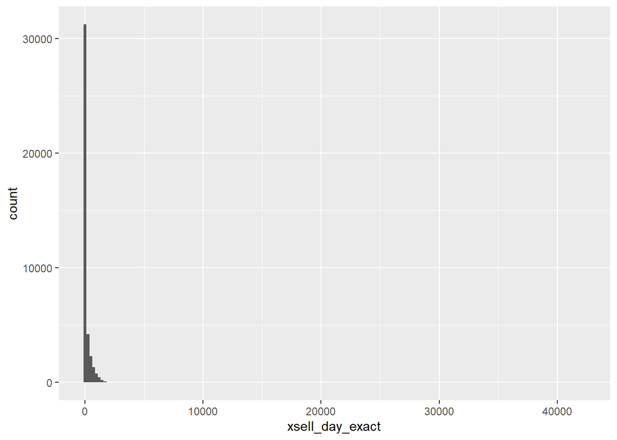

```r
ggplot(data) +
  geom_histogram(mapping = aes(x = xsell_day_exact), binwidth = 240)
```

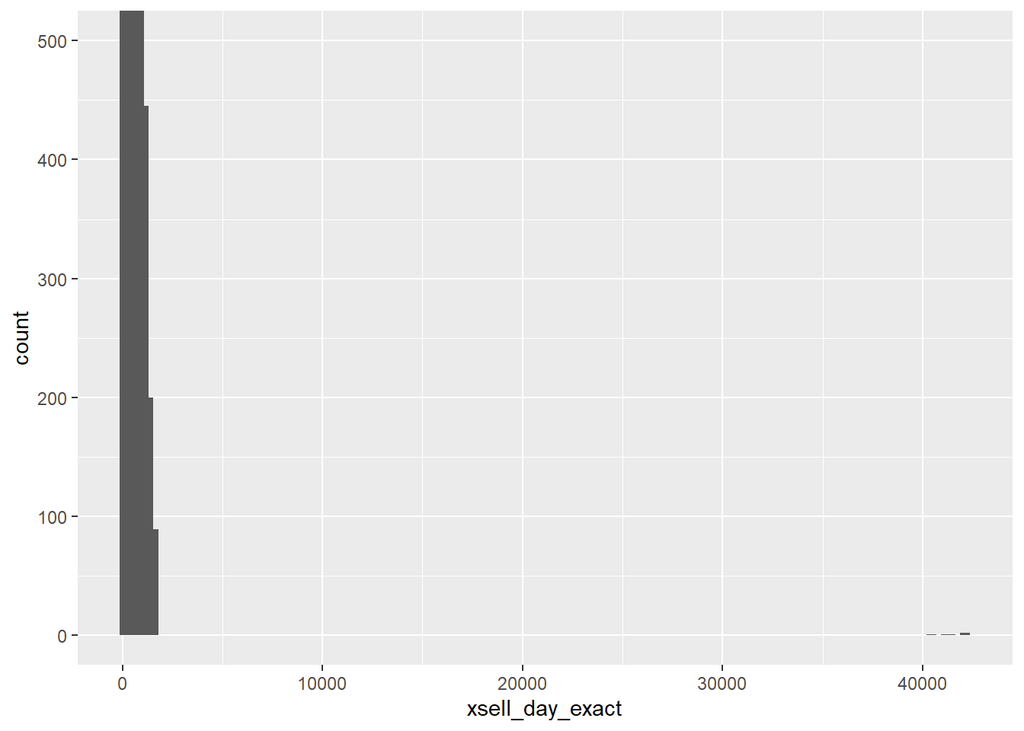

```r
ggplot(data) +
  geom_histogram(mapping = aes(x = xsell_day_exact), binwidth = 240) +
  coord_cartesian(ylim = c(0, 500))
```

```r
target %>%
  count(cut_width(xsell_day_exact, 240))
```

```
##    cut_width(xsell_day_exact, 240)      n
## 1                       [-120,120]  31216
## 2                        (120,360]   4223
## 3                        (360,600]   2285
## 4                        (600,840]   1331
## 5                   (840,1.08e+03]    781
## 6              (1.08e+03,1.32e+03]    445
## 7              (1.32e+03,1.56e+03]    200
## 8               (1.56e+03,1.8e+03]     89
## 9              (4.02e+04,4.04e+04]      1
## 10             (4.04e+04,4.07e+04]      1
## 11             (4.09e+04,4.12e+04]      1
## 12             (4.12e+04,4.14e+04]      1
## 13             (4.14e+04,4.16e+04]      1
## 14             (4.19e+04,4.21e+04]      2
## 15             (4.21e+04,4.24e+04]      2
## 16                            <NA> 211363
```

From both the inspection and visualization of the distribution for xsell_day_exact, we can see that the customer purchased ACOM subscription within 120 days of DNA product order is quite common. In general, typical values lays between 0 and 1800 while there are about 9 outliers ranging above 40000 days. Assume that each year has 365.25 days, we know that 40000 days would be about 109 years, so it is reasonable to suspect that these values are implausible. We could drop the rows with these unusual values or replacing the unusual values with missing values to move on with the analysis.  
Though, consider the total number of customers and the criteria we are using for this specific question, these values would not have effect on our analysis, so it is fine to leave it like this.

```r
dt2 <- dt %>%
  filter(xsell_day_exact <= 120)

cross_sell <- nrow(dt2)

cross_sell_rate <- cross_sell/total_customers
```

Therefore, there are 31216 customers who are cross sell (from DNA to ACOM subscription), about 12.39% of the total observed customers from Ancestry dataset.